# 21_trigs_from_uc_point_Q1

## 21_trigs_from_uc_point_Q1

#### Question

1. A unit circle is drawn centered at the origin. A ray emanates from the origin at an angle of $\theta$ radians and intersects the unit circle at point $(0.815, 0.579)$, as shown below.

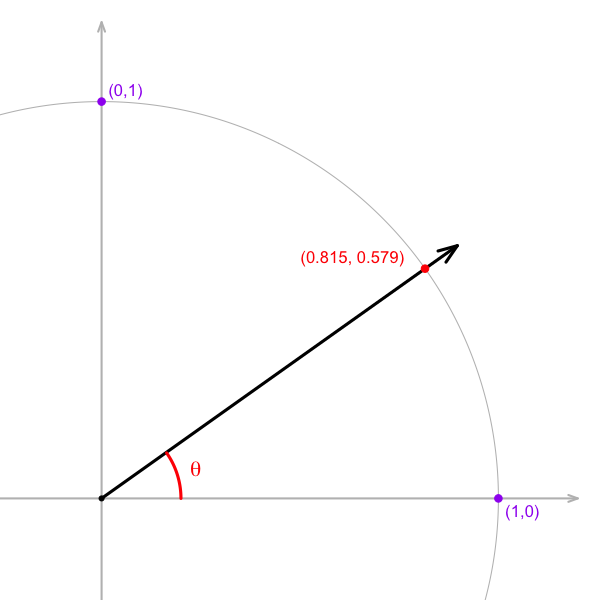

   Evaluate the following trigonometric functions:
   - $\sin(\theta)=$
   - $\cos(\theta)=$
   - $\tan(\theta)=$

   Also, find the angle measure, $\theta$, in radians.
   - $\theta=$

#### Question

2. A unit circle is drawn centered at the origin. A ray emanates from the origin at an angle of $\theta$ radians and intersects the unit circle at point $(0.352, 0.936)$, as shown below.

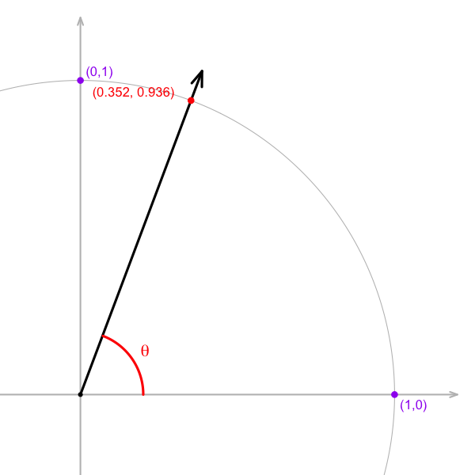

   Evaluate the following trigonometric functions:
   - $\sin(\theta)=$
   - $\cos(\theta)=$
   - $\tan(\theta)=$

   Also, find the angle measure, $\theta$, in radians.
   - $\theta=$

#### Question

3. A unit circle is drawn centered at the origin. A ray emanates from the origin at an angle of $\theta$ radians and intersects the unit circle at point $(0.772, 0.636)$, as shown below.

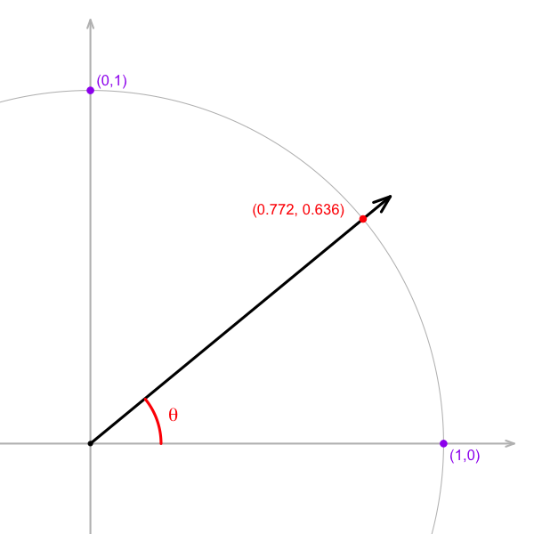

   Evaluate the following trigonometric functions:
   - $\sin(\theta)=$
   - $\cos(\theta)=$
   - $\tan(\theta)=$

   Also, find the angle measure, $\theta$, in radians.
   - $\theta=$

#### Question

4. A unit circle is drawn centered at the origin. A ray emanates from the origin at an angle of $\theta$ radians and intersects the unit circle at point $(0.341, 0.94)$, as shown below.

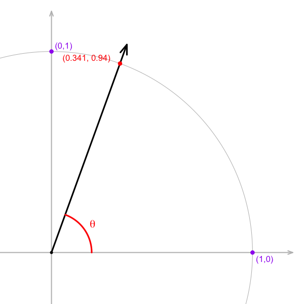

   Evaluate the following trigonometric functions:
   - $\sin(\theta)=$
   - $\cos(\theta)=$
   - $\tan(\theta)=$

   Also, find the angle measure, $\theta$, in radians.
   - $\theta=$

#### Question

5. A unit circle is drawn centered at the origin. A ray emanates from the origin at an angle of $\theta$ radians and intersects the unit circle at point $(0.529, 0.848)$, as shown below.

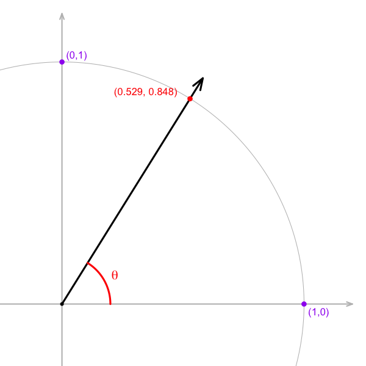

   Evaluate the following trigonometric functions:
   - $\sin(\theta)=$
   - $\cos(\theta)=$
   - $\tan(\theta)=$

   Also, find the angle measure, $\theta$, in radians.
   - $\theta=$

#### Question

6. A unit circle is drawn centered at the origin. A ray emanates from the origin at an angle of $\theta$ radians and intersects the unit circle at point $(0.753, 0.658)$, as shown below.

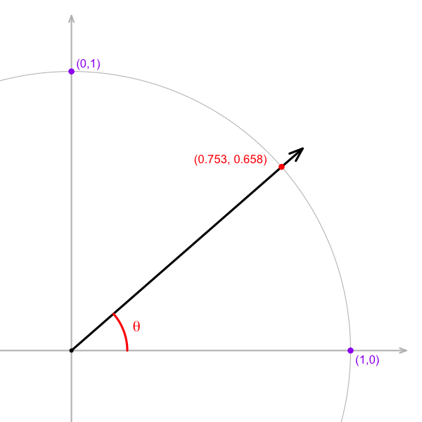

   Evaluate the following trigonometric functions:
   - $\sin(\theta)=$
   - $\cos(\theta)=$
   - $\tan(\theta)=$

   Also, find the angle measure, $\theta$, in radians.
   - $\theta=$

#### Question

7. A unit circle is drawn centered at the origin. A ray emanates from the origin at an angle of $\theta$ radians and intersects the unit circle at point $(0.598, 0.801)$, as shown below.

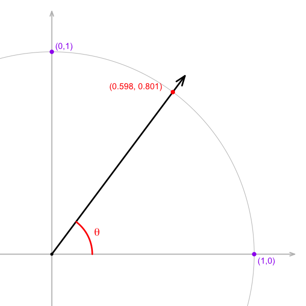

   Evaluate the following trigonometric functions:
   - $\sin(\theta)=$
   - $\cos(\theta)=$
   - $\tan(\theta)=$

   Also, find the angle measure, $\theta$, in radians.
   - $\theta=$

#### Question

8. A unit circle is drawn centered at the origin. A ray emanates from the origin at an angle of $\theta$ radians and intersects the unit circle at point $(0.494, 0.87)$, as shown below.

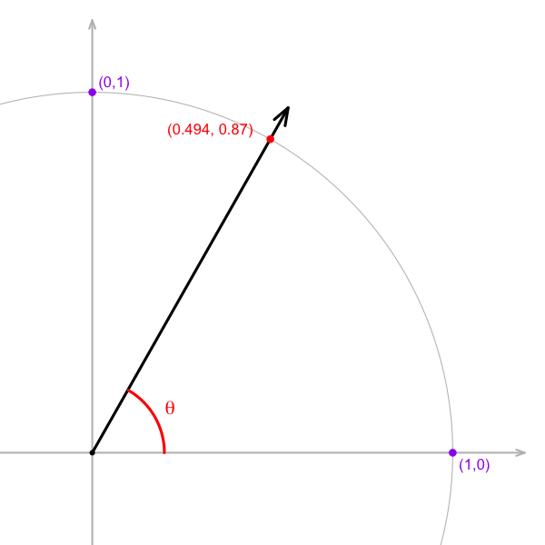

   Evaluate the following trigonometric functions:
   - $\sin(\theta)=$
   - $\cos(\theta)=$
   - $\tan(\theta)=$

   Also, find the angle measure, $\theta$, in radians.
   - $\theta=$